# Description des variables du projet

# Contexte Scientifique

*[Fourni dans le jeux de données]*

Le golfe de Gascogne abrite une communauté de cétacés parmi les plus diversifiées d’Europe : dauphins communs sur le plateau, globicéphales et rorquals sur le talus, cachalots dans les canyons profonds. Ces animaux ne sont pas répartis au hasard : ils suivent la ressource, elle-même concentrée là où la topographie force la remontée d’eaux riches — talus continental, têtes de canyons.

Recenser ces populations pose un problème méthodologique classique : on ne compte jamais les animaux présents, seulement ceux que l’on a vus. Un transect long donne plus d’observations qu’un transect court, et une mer agitée en fait manquer beaucoup. L’analyse doit donc démêler l’abondance réelle de l’effort et des conditions d’observation.

Le fichier 05_cetaces.gpkg contient les 540 transects sous forme de points (le point représente le centre du transect), en WGS84 (EPSG:4326). L’emprise couvre environ 1 000 km de diagonale, du plateau armoricain à la plaine abyssale du golfe.

Les transects ne sont pas répartis uniformément : la campagne a concentré son effort là où les observations étaient attendues. La colonne id permet de rejoindre le tableau CSV et la couche.

```r
cetaces <- read.table("../jeux_de_donnees/Cetaces_Transects.csv", header = TRUE, sep = ";", dec = ".", comment.char = "#") |>
  mutate(across(c(secteur, saison, etat_mer_beaufort), as.factor),
         presence = presence == 1)

dplyr::glimpse(cetaces)
```

```
## Rows: 540
## Columns: 15
## $ id                    <chr> "CET_0001", "CET_0002", "CET_0003", "CET_0004", …
## $ secteur               <fct> Canyon, Talus, Canyon, Canyon, Canyon, Talus, Ta…
## $ saison                <fct> Ete, Ete, Automne, Automne, Ete, Printemps, Auto…
## $ espece_dominante      <chr> "Aucune", "Aucune", "Cachalot", "Aucune", "Dauph…
## $ effort_km             <dbl> 5.9, 16.0, 6.7, 36.7, 32.9, 8.9, 37.2, 33.3, 34.…
## $ etat_mer_beaufort     <fct> 3, 4, 3, 3, 4, 2, 4, 3, 2, 4, 2, 4, 2, 2, 3, 4, …
## $ profondeur_m          <int> 359, 546, 447, 443, 853, 830, 1965, 3289, 2805, …
## $ distance_cote_km      <dbl> 103.5, 116.3, 97.1, 116.0, 125.4, 139.1, 195.0, …
## $ sst_c                 <dbl> 13.87, 13.60, 12.95, 11.54, 15.69, 11.42, 10.50,…
## $ chlorophylle_mgm3     <dbl> 0.124, 0.080, 0.283, 0.095, 0.209, 0.128, 0.646,…
## $ nb_groupes_observes   <int> 0, 0, 2, 0, 5, 0, 1, 1, 1, 0, 0, 3, 1, 5, 1, 0, …
## $ taille_groupe_moyenne <dbl> NA, NA, 2.3, NA, 5.1, NA, 1.4, 12.1, 7.7, NA, NA…
## $ presence              <lgl> FALSE, FALSE, TRUE, FALSE, TRUE, FALSE, TRUE, TR…
## $ lon                   <dbl> -6.04321, -6.06716, -2.47690, -5.84505, -2.96964…
## $ lat                   <dbl> 47.86036, 47.56678, 44.58569, 47.35168, 44.58033…
```

# Les Variables

*[Informations fournies dans le jeux de données]* Le tableau contient les variables suivantes. Le type de chaque variable n’est volontairement pas précisé : l’identifier, et en tirer les conséquences pour le choix de vos analyses, fait partie du travail demandé.

## Détails d’échantillonage

### Coordonnées

**Signification**: Donnent le centre du transect traversé.

**Type**: Coordonnées, quantitative continu

**Unités**: Dégrés décimaux, WGS84, EPSG:4326

| variable | min | median | mean | stdev | q25 | q75 | max |
| --- | --- | --- | --- | --- | --- | --- | --- |
| lat | 43.33029 | 46.36170 | 46.197857 | 1.703764 | 44.60992 | 47.467998 | 50.28577 |
| lon | -9.64603 | -3.37099 | -4.450504 | 2.309789 | -6.37197 | -2.411758 | -1.30573 |

### Saison

`cetaces$saison`

**Signification**: La saison de l’observation.

**Type**: Facteur à quatre niveaux. Hiver, Printemps, Ete, Automne. Qualitative nominale.

**Unités**: N/A

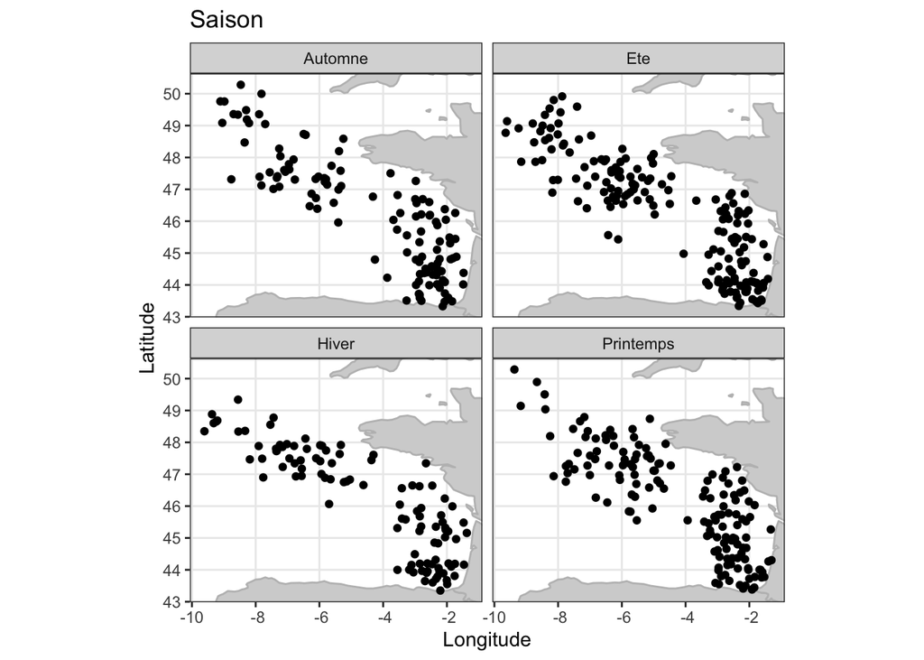

### Effort d’échantillonage

`cetaces$effort_km`

**Signification**: Le longueur du transect parcouru en veille.

**Type**: Quantitative continu

**Unités**: kilomètres

| variable | min | median | mean | stdev | q25 | q75 | max |
| --- | --- | --- | --- | --- | --- | --- | --- |
| effort_km | 5.3 | 22.35 | 22.78204 | 10.1073 | 14 | 31.725 | 40 |

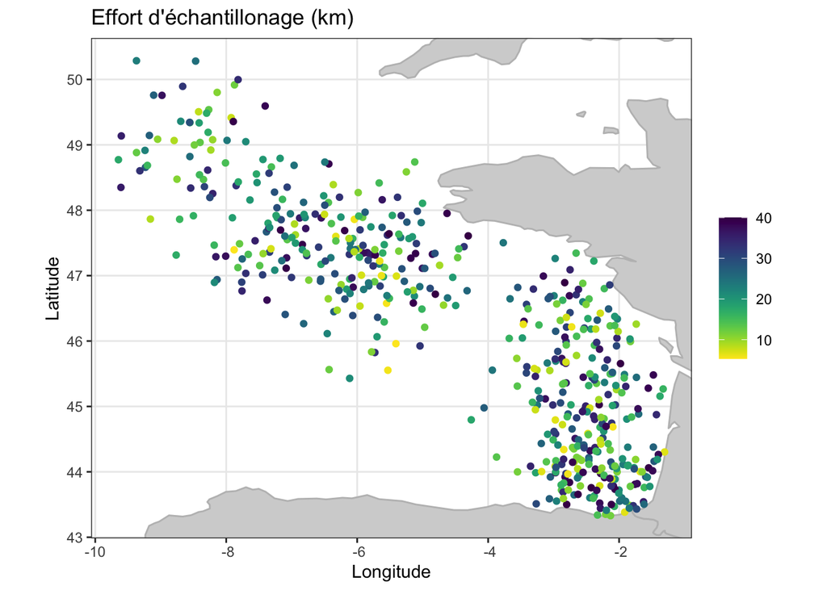

## État de mer

`cetaces$etat_mer_beaufort`

**Signification**: L’état de la mer pendant l’observation selon [l’échelle de Beaufort](https://www.station-meteo.com/outils/echelle-beaufort).

**Type**: Facteur à sept niveaux, 0-6. Calme (vitesse du vent < 1 km/h) à vent frais (39-49 km/h). Qualitative ordinale.

**Unités**: Le niveau du facteur corréspond à une vitesse du vent en km/h.

| etat_mer_beaufort | n | proportion |
| --- | --- | --- |
| 0 | 21 | 0.0388889 |
| 1 | 85 | 0.1574074 |
| 2 | 158 | 0.2925926 |
| 3 | 160 | 0.2962963 |
| 4 | 87 | 0.1611111 |
| 5 | 26 | 0.0481481 |
| 6 | 3 | 0.0055556 |

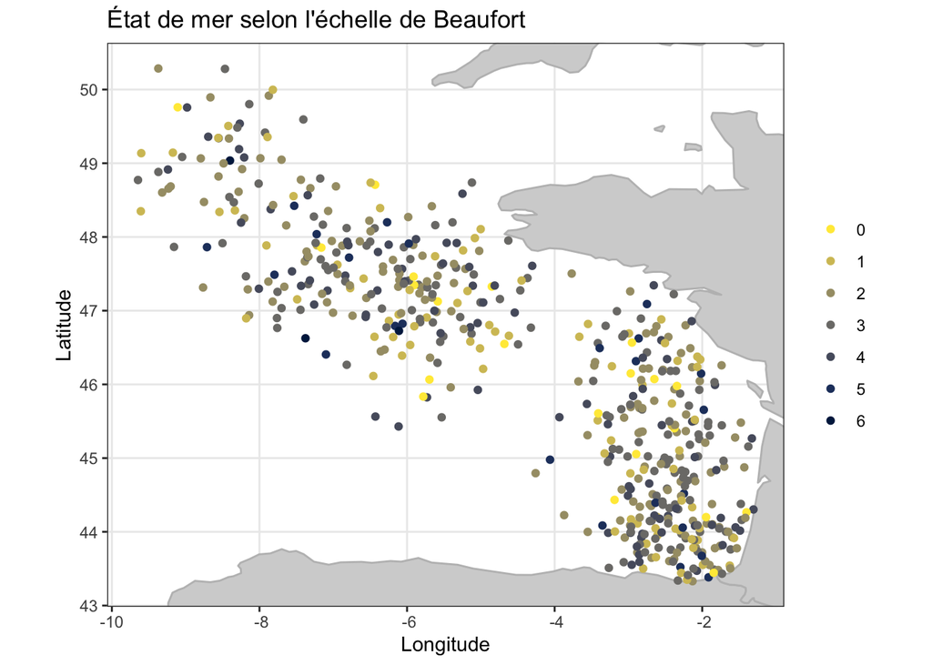

### ID

`cetaces$id`

**Signification**: L’identifiant du transect. Il sert à joindre le tableau à la couche géographique pour les couches SIG.

**Type**: String du format “CET_XXXX”, ou XXXX varie entre 0001 à 0540. Qualitative nominale.

**Unités**: N/A

## Contexte Environnementale

### Secteur

`cetaces$secteur`

**Signification**: Le secteur bathymétrique du transect, i.e. le terrain au fond.

**Type**: Facteur à quatre niveaux. Plateau, Talus, Canyon, Plaine abyssale.

**Unités**: N/A

| secteur | n | proportion |
| --- | --- | --- |
| Canyon | 198 | 0.3666667 |
| Plaine abyssale | 90 | 0.1666667 |
| Plateau | 155 | 0.2870370 |
| Talus | 97 | 0.1796296 |

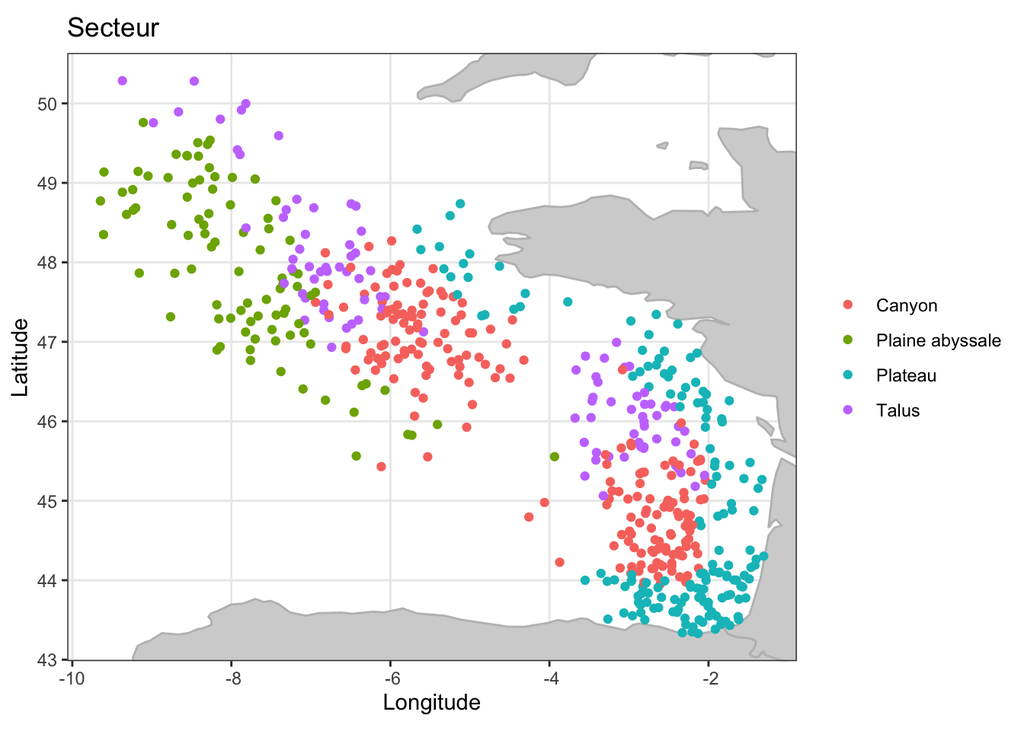

### Profondeur

`cetaces$profondeur_m`

**Signification**: Le profondeur moyenne le long du transect.

**Type**: Quantitative continu

**Unités**: mètres

| variable | min | median | mean | stdev | q25 | q75 | max |
| --- | --- | --- | --- | --- | --- | --- | --- |
| profondeur_m | 67 | 444.5 | 991.9463 | 1169.166 | 181.75 | 1515 | 4800 |

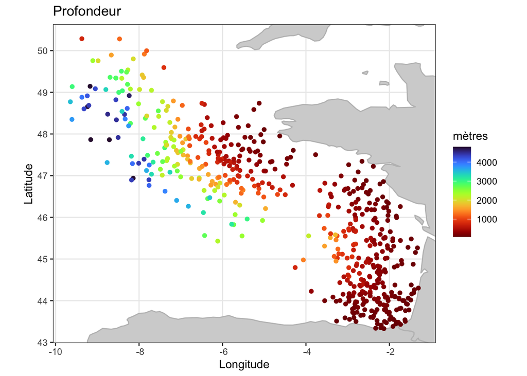

### Distance à la côte

`cetaces$distance_cote_km`

**Signification**: La distance à la côte (on présume depuis le centre du transect)

**Type**: Quantitative continu

**Unités**: kilomètres

| variable | min | median | mean | stdev | q25 | q75 | max |
| --- | --- | --- | --- | --- | --- | --- | --- |
| distance_cote_km | 0.1 | 103.1 | 116.9239 | 74.88893 | 59.625 | 167.3 | 345.4 |

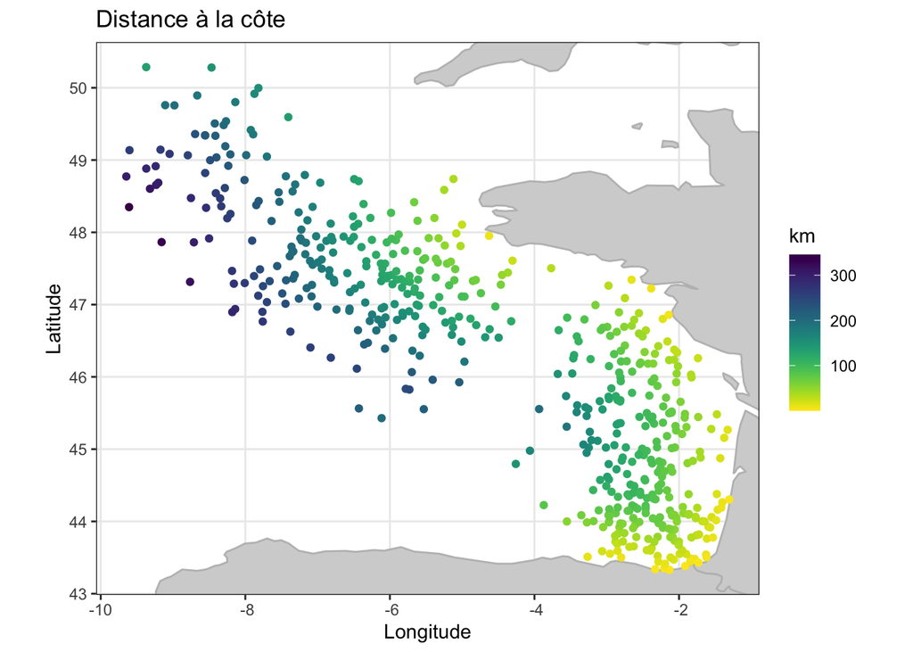

### SST

`cetaces$sst_c`

**Signification**: La température de surface de la mer. Pas spécifié s’il s’agit de température de la moyenne du transect ou du point centre.

**Type**: Quantitative continu

**Unités**: °C

| variable | min | median | mean | stdev | q25 | q75 | max |
| --- | --- | --- | --- | --- | --- | --- | --- |
| sst_c | 10.5 | 11.78 | 12.35141 | 1.782563 | 10.6875 | 14.07 | 16.49 |

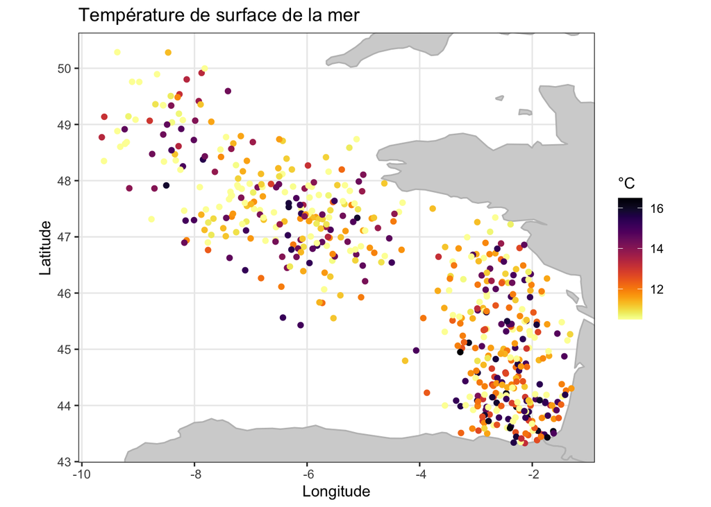

### Chlorophylle

`cetaces$chlorophylle_mgm3`

**Signification**: La concentration en chlorophylle. Pas spécifié s’il s’agit de la chlorophylle moyenne ou au point centre.

**Type**: Quantitative continu

**Unités**: mg/m³

| variable | min | median | mean | stdev | q25 | q75 | max |
| --- | --- | --- | --- | --- | --- | --- | --- |
| chlorophylle_mgm3 | 0.08 | 0.1675 | 0.2620241 | 0.2522781 | 0.095 | 0.32325 | 1.889 |

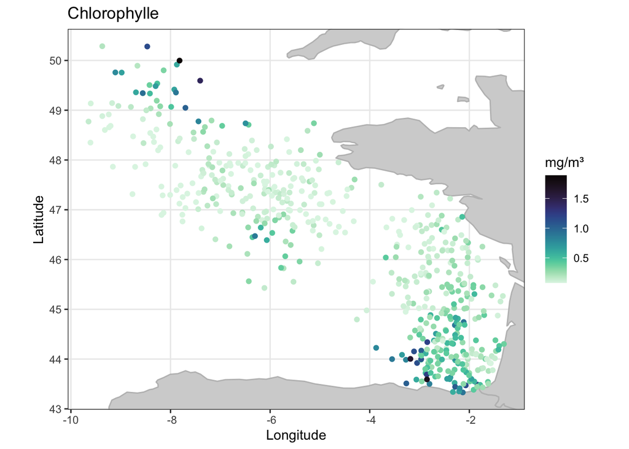

## Variables d’Observation des Cétacés

### Presence

`cetaces$presence`

**Signification**: Si au moins un groupe a été observé sur le transect. *Notez bien qu’on spécifie “observé”, une “absence” ne veut forcement pas dire qu’il n’y avait pas des cétacés!*

**Type**: Boolean (à partir de 0/1)

**Unités**: N/A

| presence | n | proportion |
| --- | --- | --- |
| FALSE | 270 | 0.5 |
| TRUE | 270 | 0.5 |

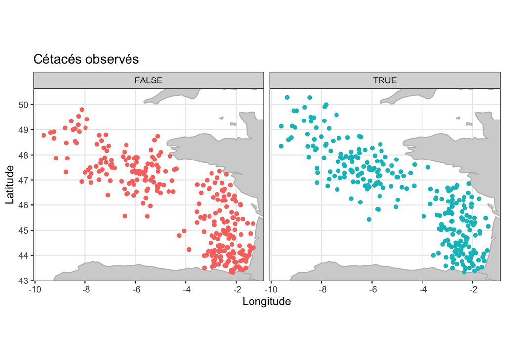

### Nombre de groupes observés

`cetaces$nb_groupes_observes`

**Signification**: Le nombre de groupes de cétacés détectés sur le transect

**Type**: Quantitative discrète

**Unités**: groupes

| variable | min | median | mean | stdev | q25 | q75 | max |
| --- | --- | --- | --- | --- | --- | --- | --- |
| nb_groupes_observes | 0 | 0.5 | 1.42037 | 2.477946 | 0 | 2 | 20 |

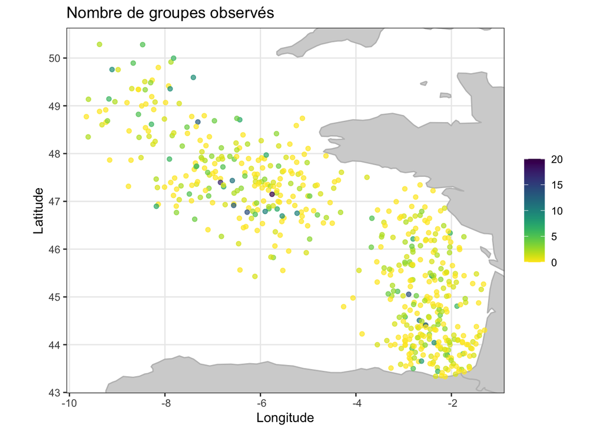

### Taille moyenne des groupes

`cetaces$taille_groupe_moyenne`

**Signification**: La taille moyenne (i.e. nombre d’individus) des groupes observés le long d’un transect. Renseigné uniquement si au moins un groupe a été vu.

**Type**: Quantitative continu

**Unités**: individus

| variable | min | median | mean | stdev | q25 | q75 | max |
| --- | --- | --- | --- | --- | --- | --- | --- |
| taille_groupe_moyenne | 1 | 4.95 | 7.601482 | 7.076507 | 2.5 | 10.3 | 37.2 |

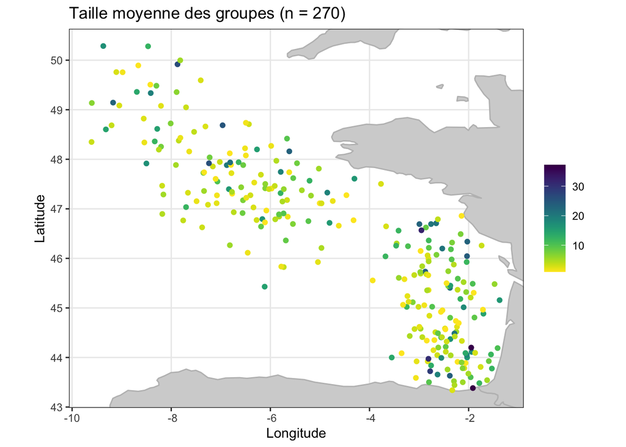

### Espèce Dominante

`cetaces$espece_dominante`

**Signification**: L’espèce dominante observée sur le transect (ou “aucune”).

**Type**: Facteur à cinq niveaux. Aucune, Dauphin commun, Globicephale, Rorqual commun, Cachalot. Qualitative Nominale.

**Unités**: N/A

| espece_dominante | n | proportion |
| --- | --- | --- |
| Aucune | 270 | 0.5000000 |
| Cachalot | 59 | 0.1092593 |
| Dauphin commun | 91 | 0.1685185 |
| Globicephale | 58 | 0.1074074 |
| Rorqual commun | 62 | 0.1148148 |

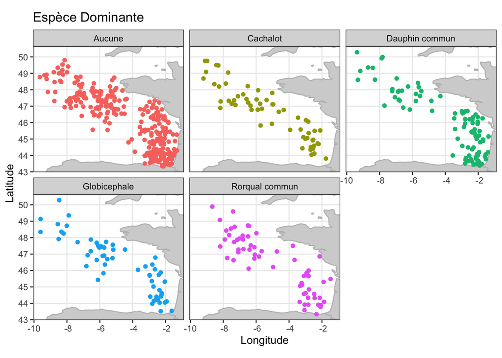